# Importing Data in R (Part 2)

William Surles

2017-07-06

# Introduction

Course notes for [Importing Data in R (Part 2)](https://www.datacamp.com/courses/importing-data-in-r-part-2)

## Whats Covered

- Importing data from databases
  - `DBI`, `RMySQL`, SQL examples
  - connecting, fetching and disconnecting from DB
- Importing data from the web
  - HTTP, HTTPS,
  - `readr`, `gdata`, and `readxl` from the web,
  - `httr`
  - JSON and `jsonlite`
- Importing data form statistical sofware packages
  - `haven` and `foreign` with SAS, STATA, and SPSS files

# Importing data from databases (1)

## Connect to a database

- There are different packages for differnt database managment systems (DBMS)
- RMySQL, RPostgres, ROracle, etc
- All of these use DBI to connect

## Establish a connection

- They have set up a database on aws that I can connect to for the exercise
- You only need to connect once and then can run multiple queries on the data as I will do below

```r
## The DBI package is already loaded

# Edit dbConnect() call
con <- dbConnect(RMySQL::MySQL(),
                 dbname = "tweater",
                 host = "courses.csrrinzqubik.us-east-1.rds.amazonaws.com",
                 port = 3306,
                 user = "student",
                 password = "datacamp")
```

## Inspect the connection

- Con is a connection to the MySQL DB

```r
class(con)
```

```
## [1] "MySQLConnection"
## attr(,"package")
## [1] "RMySQL"
```

## List the database tables

```r
## The DBI package is already loaded

## The MySQL database connection is already made with con

# Build a vector of table names: tables
tables <- dbListTables(con)

# Display structure of tables
str(tables)
```

```
##  chr [1:3] "comments" "tweats" "users"
```

## Import users

```r
# Import the users table from tweater: users
users <- dbReadTable(con, "users")

# Print users
users
```

```
##   id      name     login
## 1  1 elisabeth  elismith
## 2  2      mike     mikey
## 3  3      thea   teatime
## 4  4    thomas tomatotom
## 5  5    oliver olivander
## 6  6      kate  katebenn
## 7  7    anjali    lianja
```

## Import all tables

```r
# Get table names
table_names <- dbListTables(con)

# Import all tables
tables <- lapply(table_names, dbReadTable, conn = con)

# Print out tables
tables
```

```
## [[1]]
##      id tweat_id user_id            message
## 1  1022       87       7              nice!
## 2  1000       77       7             great!
## 3  1011       49       5            love it
## 4  1012       87       1   awesome! thanks!
## 5  1010       88       6              yuck!
## 6  1026       77       4      not my thing!
## 7  1004       49       1  this is fabulous!
## 8  1030       75       6           so easy!
## 9  1025       88       2             oh yes
## 10 1007       49       3           serious?
## 11 1020       77       1 couldn't be better
## 12 1014       77       1       saved my day
##
```

[output cut: 32 more lines]

# Importing data from databases (2)

## SQL Queries from inside R

- Running SQL queries in the DB is much more efficient than loading all of the data into R and then crunching
  - Escpecially for large table that are many millions of rows.
  - Its best to query just the data you need from the table or crunch it in a sql query with a group by and summarize
  - Its not covered in this class but you can also write dplyr code and it will automtically convert it to sql and run it in the DB.

## Query tweater (1)

```r
# Import tweat_id column of comments where user_id is 1: elisabeth
elisabeth <- dbGetQuery(con, "select tweat_id from comments where user_id =  1")

# Print elisabeth
elisabeth
```

```
##   tweat_id
## 1       87
## 2       49
## 3       77
## 4       77
```

## Query tweater (2)

```r
# Import post column of tweats where date is higher than '2015-09-21': latest
latest <- dbGetQuery(con, "select post from tweats where date > '2015-09-21'")

# Print latest
latest
```

```
##                                                                  post
## 1               open and crush avocado. add shrimps. perfect starter.
## 2 nachos. add tomato sauce, minced meat and cheese. oven for 10 mins.
## 3                              just eat an apple. simply and healthy.
```

## Query tweater (3)

```r
# Create data frame specific
specific <- dbGetQuery(con, "select message from comments where tweat_id = 77 AND user_id > 4")

# Print specific
specific
```

```
##   message
## 1  great!
```

## Query tweater (4)

```r
# Create data frame short
short <- dbGetQuery(con, "select id, name from users where CHAR_LENGTH(name) < 5")

# Print short
short
```

```
##   id name
## 1  2 mike
## 2  3 thea
## 3  6 kate
```

## Join the query madness!

```r
sql <- "SELECT post, message
        FROM tweats INNER JOIN comments on tweats.id = tweat_id
        WHERE tweat_id = 77"
df <- dbGetQuery(con, sql)
df
```

```
##                                            post            message
## 1 2 slices of bread. add cheese. grill. heaven.             great!
## 2 2 slices of bread. add cheese. grill. heaven.      not my thing!
## 3 2 slices of bread. add cheese. grill. heaven. couldn't be better
## 4 2 slices of bread. add cheese. grill. heaven.       saved my day
```

## DBI internals

- Sometimes you want to control the data that is fetched
- If so, you can use the DBI internal functions `dbSendQuery`, `dbFetch`, and `dbClearResults`

## Send - Fetch - Clear

```r
# Send query to the database
res <- dbSendQuery(con, "SELECT * FROM comments WHERE user_id > 4")

# Use dbFetch() twice
dbFetch(res, 2)
```

```
##     id tweat_id user_id message
## 1 1022       87       7   nice!
## 2 1000       77       7  great!
```

```r
dbFetch(res, 2)
```

```
##     id tweat_id user_id message
## 1 1011       49       5 love it
## 2 1010       88       6   yuck!
```

```r
# Clear res
dbClearResult(res)
```

```
## [1] TRUE
```

## Be polite and …

- Always disconnect from the database when you are done querying

```r
# Create the data frame  long_tweats
long_tweats <- dbGetQuery(con, "select post, date from tweats where CHAR_LENGTH(post) > 40")

# Print long_tweats
long_tweats
```

```
##                                                                  post
## 1                           wash strawberries. add ice. blend. enjoy.
## 2                       2 slices of bread. add cheese. grill. heaven.
## 3               open and crush avocado. add shrimps. perfect starter.
## 4 nachos. add tomato sauce, minced meat and cheese. oven for 10 mins.
##         date
## 1 2015-09-14
## 2 2015-09-21
## 3 2015-09-22
## 4 2015-09-22
```

```r
# Disconnect from the database
dbDisconnect(con)
```

```
## [1] TRUE
```

# Importing data from the web (1)

## HTTP

- More and more data will be on the web
- Or atleast on a remote server with http/https access
- So its important to know that you can get data via an http request
- This is simply asking a remove server for a file

## Import flat files from the web

- readr can grab a file from the web directly.
- It knows the location is a url and it will just work

```r
# The readr package is already loaded

# Import the csv file: pools
url_csv <- "http://s3.amazonaws.com/assets.datacamp.com/production/course_1478/datasets/swimming_pools.csv"
pools <- read_csv(url_csv)
head(pools)
```

```
## # A tibble: 6 x 4
##                          Name                                    Address
##                         <chr>                                      <chr>
## 1 Acacia Ridge Leisure Centre         1391 Beaudesert Road, Acacia Ridge
## 2             Bellbowrie Pool               Sugarwood Street, Bellbowrie
## 3                 Carole Park Cnr Boundary Road and Waterford Road Wacol
## 4 Centenary Pool (inner City)           400 Gregory Terrace, Spring Hill
## 5              Chermside Pool               375 Hamilton Road, Chermside
## 6 Colmslie Pool (Morningside)               400 Lytton Road, Morningside
## # ... with 2 more variables: Latitude <dbl>, Longitude <dbl>
```

```r
# Import the txt file: potatoes
url_delim <- "http://s3.amazonaws.com/assets.datacamp.com/production/course_1478/datasets/potatoes.txt"
potatoes <- read_tsv(url_delim)
head(potatoes)
```

```
## # A tibble: 6 x 8
##    area  temp  size storage method texture flavor moistness
##   <int> <int> <int>   <int>  <int>   <dbl>  <dbl>     <dbl>
## 1     1     1     1       1      1     2.9    3.2       3.0
## 2     1     1     1       1      2     2.3    2.5       2.6
## 3     1     1     1       1      3     2.5    2.8       2.8
## 4     1     1     1       1      4     2.1    2.9       2.4
## 5     1     1     1       1      5     1.9    2.8       2.2
## 6     1     1     1       2      1     1.8    3.0       1.7
```

## Secure importing

- This also works for https

```r
# https URL to the swimming_pools csv file.
url_csv <- "https://s3.amazonaws.com/assets.datacamp.com/production/course_1478/datasets/swimming_pools.csv"

# Import the file using read.csv(): pools1
pools1 <- read.csv(url_csv)
str(pools1)
```

```
## 'data.frame':    20 obs. of  4 variables:
##  $ Name     : Factor w/ 20 levels "Acacia Ridge Leisure Centre",..: 1 2 3 4 5 6 19 7 8 9 ...
##  $ Address  : Factor w/ 20 levels "1 Fairlead Crescent, Manly",..: 5 20 18 10 9 11 6 15 12 17 ...
##  $ Latitude : num  -27.6 -27.6 -27.6 -27.5 -27.4 ...
##  $ Longitude: num  153 153 153 153 153 ...
```

```r
# Import the file using read_csv(): pools2
pools2 <- read_csv(url_csv)
str(pools2)
```

```
## Classes 'tbl_df', 'tbl' and 'data.frame':    20 obs. of  4 variables:
##  $ Name     : chr  "Acacia Ridge Leisure Centre" "Bellbowrie Pool" "Carole Park" "Centenary Pool (inner City)" ...
##  $ Address  : chr  "1391 Beaudesert Road, Acacia Ridge" "Sugarwood Street, Bellbowrie" "Cnr Boundary Road and Waterford Road Wacol" "400 Gregory Terrace, Spring Hill" ...
##  $ Latitude : num  -27.6 -27.6 -27.6 -27.5 -27.4 ...
##  $ Longitude: num  153 153 153 153 153 ...
##  - attr(*, "spec")=List of 2
##   ..$ cols   :List of 4
##   .. ..$ Name     : list()
##   .. .. ..- attr(*, "class")= chr  "collector_character" "collector"
##   .. ..$ Address  : list()
##   .. .. ..- attr(*, "class")= chr  "collector_character" "collector"
##   .. ..$ Latitude : list()
##   .. .. ..- attr(*, "class")= chr  "collector_double" "collector"
##   .. ..$ Longitude: list()
##   .. .. ..- attr(*, "class")= chr  "collector_double" "collector"
##   ..$ default: list()
##   .. ..- attr(*, "class")= chr  "collector_guess" "collector"
##   ..- attr(*, "class")= chr "col_spec"
```

## Downloading files

- readxl can’t pull excel files from http yet but you can download it and then read it in
- or use gdata package to get it directly from the web

## Import Excel files form the web

```r
# The readxl and gdata packages are already loaded

# Specification of url: url_xls
url_xls <- "http://s3.amazonaws.com/assets.datacamp.com/production/course_1478/datasets/latitude.xls"

# Import the .xls file with gdata: excel_gdata
excel_gdata <- read.xls(url_xls)
str(excel_gdata)
```

```
## 'data.frame':    246 obs. of  2 variables:
##  $ country: Factor w/ 246 levels "\xc5land","Afghanistan",..: 2 3 4 5 6 7 8 9 10 11 ...
##  $ X1700  : num  34.6 34.6 41.3 36.7 -14.3 ...
```

```r
# Download file behind URL, name it local_latitude.xls
download.file(url_xls,"data/local_latitude.xls")

# Import the local .xls file with readxl: excel_readxl
excel_readxl <- read_excel("data/local_latitude.xls")
str(excel_readxl)
```

```
## Classes 'tbl_df', 'tbl' and 'data.frame':    246 obs. of  2 variables:
##  $ country: chr  "Afghanistan" "Akrotiri and Dhekelia" "Albania" "Algeria" ...
##  $ 1700   : num  34.6 34.6 41.3 36.7 -14.3 ...
```

## Downloading any file, secure or not

- the `load` used to load `Rdata` files does not accept urls so if there is an `RData` file on the web you will need to download it first
- you can pretty much download any file with `download.file`

```r
# https URL to the wine RData file.
url_rdata <- "https://s3.amazonaws.com/assets.datacamp.com/production/course_1478/datasets/wine.RData"

# Download the wine file to your working directory
download.file(url_rdata, "data/wine_local.RData")

# Load the wine data into your workspace using load()
load("data/wine_local.RData")

# Print out the summary of the wine data
summary(wine)
```

```
##     Alcohol        Malic acid        Ash        Alcalinity of ash
##  Min.   :11.03   Min.   :0.74   Min.   :1.360   Min.   :10.60
##  1st Qu.:12.36   1st Qu.:1.60   1st Qu.:2.210   1st Qu.:17.20
##  Median :13.05   Median :1.87   Median :2.360   Median :19.50
##  Mean   :12.99   Mean   :2.34   Mean   :2.366   Mean   :19.52
##  3rd Qu.:13.67   3rd Qu.:3.10   3rd Qu.:2.560   3rd Qu.:21.50
##  Max.   :14.83   Max.   :5.80   Max.   :3.230   Max.   :30.00
##    Magnesium      Total phenols     Flavanoids    Nonflavanoid phenols
##  Min.   : 70.00   Min.   :0.980   Min.   :0.340   Min.   :0.1300
##  1st Qu.: 88.00   1st Qu.:1.740   1st Qu.:1.200   1st Qu.:0.2700
##  Median : 98.00   Median :2.350   Median :2.130   Median :0.3400
##  Mean   : 99.59   Mean   :2.292   Mean   :2.023   Mean   :0.3623
##  3rd Qu.:107.00   3rd Qu.:2.800   3rd Qu.:2.860   3rd Qu.:0.4400
##  Max.   :162.00   Max.   :3.880   Max.   :5.080   Max.   :0.6600
##  Proanthocyanins Color intensity       Hue           Proline
##  Min.   :0.410   Min.   : 1.280   Min.   :1.270   Min.   : 278.0
##  1st Qu.:1.250   1st Qu.: 3.210   1st Qu.:1.930   1st Qu.: 500.0
##  Median :1.550   Median : 4.680   Median :2.780   Median : 672.0
##  Mean   :1.587   Mean   : 5.055   Mean   :2.604   Mean   : 745.1
##  3rd Qu.:1.950   3rd Qu.: 6.200   3rd Qu.:3.170   3rd Qu.: 985.0
##  Max.   :3.580   Max.   :13.000   Max.   :4.000   Max.   :1680.0
```

## Reading a txt file from the web

```r
## These all work
read.csv("http://s3.amazonaws.com/assets.datacamp.com/production/course_1478/datasets/swimming_pools.csv") %>% head()
```

```
##                          Name                                    Address
## 1 Acacia Ridge Leisure Centre         1391 Beaudesert Road, Acacia Ridge
## 2             Bellbowrie Pool               Sugarwood Street, Bellbowrie
## 3                 Carole Park Cnr Boundary Road and Waterford Road Wacol
## 4 Centenary Pool (inner City)           400 Gregory Terrace, Spring Hill
## 5              Chermside Pool               375 Hamilton Road, Chermside
## 6 Colmslie Pool (Morningside)               400 Lytton Road, Morningside
##    Latitude Longitude
## 1 -27.58616  153.0264
## 2 -27.56547  152.8911
## 3 -27.60744  152.9315
## 4 -27.45537  153.0251
## 5 -27.38583  153.0351
## 6 -27.45516  153.0789
```

```r
read_tsv("http://s3.amazonaws.com/assets.datacamp.com/production/course_1478/datasets/potatoes.txt") %>% head()
```

```
## # A tibble: 6 x 8
##    area  temp  size storage method texture flavor moistness
##   <int> <int> <int>   <int>  <int>   <dbl>  <dbl>     <dbl>
## 1     1     1     1       1      1     2.9    3.2       3.0
## 2     1     1     1       1      2     2.3    2.5       2.6
## 3     1     1     1       1      3     2.5    2.8       2.8
## 4     1     1     1       1      4     2.1    2.9       2.4
## 5     1     1     1       1      5     1.9    2.8       2.2
## 6     1     1     1       2      1     1.8    3.0       1.7
```

```r
download.file("http://s3.amazonaws.com/assets.datacamp.com/production/course_1478/datasets/latitude.xlsx", "data/lat.xlsx")

## This will not work. you need to download the RData file first then load it
# load("https://s3.amazonaws.com/assets.datacamp.com/production/course_1478/datasets/wine.RData")
```

## HTTP? httr! (1)

```r
# The httr package is already loaded

# Get the url, save response to resp
url <- "http://www.example.com/"
resp <- GET(url)

# Print resp
resp
```

```
## Response [http://www.example.com/]
##   Date: 2017-07-11 13:47
##   Status: 200
##   Content-Type: text/html
##   Size: 1.27 kB
## <!doctype html>
## <html>
## <head>
##     <title>Example Domain</title>
##
##     <meta charset="utf-8" />
##     <meta http-equiv="Content-type" content="text/html; charset=utf-8" />
##     <meta name="viewport" content="width=device-width, initial-scale=1" />
##     <style type="text/css">
##     body {
## ...
```

```r
# Get the raw content of resp: raw_content
raw_content <- content(resp, as='raw')

# Print the head of raw_content
head(raw_content)
```

```
## [1] 3c 21 64 6f 63 74
```

## HTTP? httr! (2)

```r
# Get the url
url <- "http://www.omdbapi.com/?apikey=ff21610b&t=Annie+Hall&y=&plot=short&r=json"
resp <- GET(url)

# Print resp
resp
```

```
## Response [http://www.omdbapi.com/?apikey=ff21610b&t=Annie+Hall&y=&plot=short&r=json]
##   Date: 2017-07-11 13:47
##   Status: 200
##   Content-Type: application/json; charset=utf-8
##   Size: 902 B
```

```r
# Print content of resp as text
content(resp, as = 'text')
```

```
## [1] "{\"Title\":\"Annie Hall\",\"Year\":\"1977\",\"Rated\":\"PG\",\"Released\":\"20 Apr 1977\",\"Runtime\":\"93 min\",\"Genre\":\"Comedy, Romance\",\"Director\":\"Woody Allen\",\"Writer\":\"Woody Allen, Marshall Brickman\",\"Actors\":\"Woody Allen, Diane Keaton, Tony Roberts, Carol Kane\",\"Plot\…
```

```r
# Print content of resp
content(resp)
```

```
## $Title
## [1] "Annie Hall"
##
## $Year
## [1] "1977"
##
## $Rated
## [1] "PG"
##
## $Released
## [1] "20 Apr 1977"
##
## $Runtime
## [1] "93 min"
##
## $Genre
## [1] "Comedy, Romance"
##
## $Director
## [1] "Woody Allen"
##
## $Writer
## [1] "Woody Allen, Marshall Brickman"
##
## $Actors
## [1] "Woody Allen, Diane Keaton, Tony Roberts, Carol Kane"
##
## $Plot
## [1] "Neurotic New York comedian Alvy Singer falls in love with the ditzy Annie Hall."
##
## $Language
## [1] "English, German"
##
## $Country
## [1] "USA"
##
## $Awards
## [1] "Won 4 Oscars. Another 26 wins & 8 nominations."
##
## $Poster
```

[output cut: 34 more lines]

```
##
## $DVD
## [1] "28 Apr 1998"
##
## $BoxOffice
## [1] "N/A"
##
## $Production
## [1] "United Artists"
##
## $Website
## [1] "N/A"
##
## $Response
## [1] "True"
```

# Importing data from the web (2)

## APIs & JSON

- APIs let you request or send data to a server via the web with
- You use a url with set parameters and the server knows what data to return
  - It handles all the sql and query stuff so you don’t need to know how the data is stored
  - You just need to know what parameters to put in the url to ask for the data you want
- It will then provide structured data in return
- JSON is the structure that is used almost always
- JSON data easily translates to a list in R which can then be converted to a dataframe

## From JSON to R

```r
# The jsonlite package is already loaded

# wine_json is a JSON
wine_json <- '{"name":"Chateau Migraine", "year":1997, "alcohol_pct":12.4, "color":"red", "awarded":false}'

# Convert wine_json into a list: wine
wine <- fromJSON(wine_json)

# Print structure of wine
str(wine)
```

```
## List of 5
##  $ name       : chr "Chateau Migraine"
##  $ year       : int 1997
##  $ alcohol_pct: num 12.4
##  $ color      : chr "red"
##  $ awarded    : logi FALSE
```

```r
wine
```

```
## $name
## [1] "Chateau Migraine"
##
## $year
## [1] 1997
##
## $alcohol_pct
## [1] 12.4
##
## $color
## [1] "red"
##
## $awarded
## [1] FALSE
```

## Quandl API

```r
# Definition of quandl_url
quandl_url <- "http://www.quandl.com/api/v1/datasets/IWS/INTERNET_INDIA.json?auth_token=i83asDsiWUUyfoypkgMz"

# Import Quandl data: quandl_data
quandl_data <- fromJSON(quandl_url)

# Print structure of quandl_data
str(quandl_data)
```

```
## List of 17
##  $ errors      : Named list()
##  $ id          : int 2351831
##  $ source_name : chr "Internet World Stats"
##  $ source_code : chr "IWS"
##  $ code        : chr "INTERNET_INDIA"
##  $ name        : chr "India Internet Usage"
##  $ urlize_name : chr "India-Internet-Usage"
##  $ display_url : chr "http://www.internetworldstats.com/asia/in.htm"
##  $ description : chr "Internet Usage and Population Statistics"
##  $ updated_at  : chr "2016-01-01T04:23:55.235Z"
##  $ frequency   : chr "annual"
##  $ from_date   : chr "1998-12-31"
##  $ to_date     : chr "2012-12-31"
##  $ column_names: chr [1:4] "YEAR" "Users" "Population" "% Pen."
##  $ premium     : logi FALSE
##  $ data        : chr [1:13, 1:4] "2012-12-31" "2010-12-31" "2009-12-31" "2007-12-31" ...
##  $ type        : chr "Time Series"
```

## OMDb API

```r
# Definition of the URLs
url_sw4 <- "http://www.omdbapi.com/?apikey=ff21610b&i=tt0076759&r=json"
url_sw3 <- "http://www.omdbapi.com/?apikey=ff21610b&i=tt0121766&r=json"

# Import two URLs with fromJSON(): sw4 and sw3
sw4 <- fromJSON(url_sw4)
sw3 <- fromJSON(url_sw3)


# Print out the Title element of both lists
sw4$Title
```

```
## [1] "Star Wars: Episode IV - A New Hope"
```

```r
sw3$Title
```

```
## [1] "Star Wars: Episode III - Revenge of the Sith"
```

```r
# Is the release year of sw4 later than sw3?
str(sw4)
```

```
## List of 25
##  $ Title     : chr "Star Wars: Episode IV - A New Hope"
##  $ Year      : chr "1977"
##  $ Rated     : chr "PG"
##  $ Released  : chr "25 May 1977"
##  $ Runtime   : chr "121 min"
##  $ Genre     : chr "Action, Adventure, Fantasy"
##  $ Director  : chr "George Lucas"
##  $ Writer    : chr "George Lucas"
##  $ Actors    : chr "Mark Hamill, Harrison Ford, Carrie Fisher, Peter Cushing"
##  $ Plot      : chr "Luke Skywalker joins forces with a Jedi Knight, a cocky pilot, a wookiee and two droids to save the galaxy from"| __truncated__
##  $ Language  : chr "English"
##  $ Country   : chr "USA"
##  $ Awards    : chr "Won 6 Oscars. Another 50 wins & 28 nominations."
##  $ Poster    : chr "https://images-na.ssl-images-amazon.com/images/M/MV5BYzQ2OTk4N2QtOGQwNy00MmI3LWEwNmEtOTk0OTY3NDk2MGJkL2ltYWdlL2"| __truncated__
##  $ Ratings   :'data.frame':  3 obs. of  2 variables:
##   ..$ Source: chr [1:3] "Internet Movie Database" "Rotten Tomatoes" "Metacritic"
##   ..$ Value : chr [1:3] "8.7/10" "93%" "92/100"
##  $ Metascore : chr "92"
##  $ imdbRating: chr "8.7"
##  $ imdbVotes : chr "982,688"
##  $ imdbID    : chr "tt0076759"
##  $ Type      : chr "movie"
##  $ DVD       : chr "21 Sep 2004"
##  $ BoxOffice : chr "N/A"
##  $ Production: chr "20th Century Fox"
##  $ Website   : chr "http://www.starwars.com/episode-iv/"
##  $ Response  : chr "True"
```

```r
sw4$Year > sw3$Year
```

```
## [1] FALSE
```

## JSON & jsonlite

- JSON is an unordered arrary of name value pairs
  - the name is a string
  - the value can be pretty much any data type, including another json object or a json array
- If each object has the same name value pairs it maps well to the rows of a data frame
  - But the data can also be very nested
- The `jsonlite` package doe a good job of pulling json data into dataframes or lists
  - And it has functions like `minify` and `prettify` to help viewing of json data

## JSON practice (1)

```r
# The jsonlite package is already loaded

# Challenge 1
json1 <- '[1, 2, 3, 4, 5, 6]'
fromJSON(json1)
```

```
## [1] 1 2 3 4 5 6
```

```r
# Challenge 2
json2 <- '{"a": [1, 2, 3], "b": [4, 5, 6]}'
fromJSON(json2)
```

```
## $a
## [1] 1 2 3
##
## $b
## [1] 4 5 6
```

## JSON practice (2)

```r
# Challenge 1
json1 <- '[[1, 2], [3, 4]]'
fromJSON(json1)
```

```
##      [,1] [,2]
## [1,]    1    2
## [2,]    3    4
```

```r
# Challenge 2
json2 <- '[{"a": 1, "b": 2}, {"a": 3, "b": 4}, {"a": 5, "b": 6}]'
fromJSON(json2)
```

```
##   a b
## 1 1 2
## 2 3 4
## 3 5 6
```

## toJSON()

```r
# URL pointing to the .csv file
url_csv <- "http://s3.amazonaws.com/assets.datacamp.com/production/course_1478/datasets/water.csv"

# Import the .csv file located at url_csv
water <- read.csv(url_csv, stringsAsFactors=F)
str(water)
```

```
## 'data.frame':    77 obs. of  5 variables:
##  $ water: chr  "Algeria" "American Samoa" "Angola" "Antigua and Barbuda" ...
##  $ X1992: num  0.064 NA 0.000138 0.0033 0.000749 ...
##  $ X1997: num  NA NA NA NA 0.000749 ...
##  $ X2002: num  0.017 NA 0.000138 NA 0.000749 ...
##  $ X2007: num  NA NA NA NA NA ...
```

```r
# Convert the data file according to the requirements
water_json <- toJSON(head(water))

# Print out water_json
water_json
```

```
## [{"water":"Algeria","X1992":0.064,"X2002":0.017},{"water":"American Samoa"},{"water":"Angola","X1992":0.0001,"X2002":0.0001},{"water":"Antigua and Barbuda","X1992":0.0033},{"water":"Argentina","X1992":0.0007,"X1997":0.0007,"X2002":0.0007},{"water":"Australia","X1992":0.0298,"X2002":0.0298}]
```

## Minify and prettify

```r
# Convert mtcars to a pretty JSON: pretty_json
## I'm going to shorten this to just 3 rows to save output space
pretty_json <- toJSON(head(mtcars,3), pretty=T)

# Print pretty_json
pretty_json
```

```
## [
##   {
##     "mpg": 21,
##     "cyl": 6,
##     "disp": 160,
##     "hp": 110,
##     "drat": 3.9,
##     "wt": 2.62,
##     "qsec": 16.46,
##     "vs": 0,
##     "am": 1,
##     "gear": 4,
##     "carb": 4,
##     "_row": "Mazda RX4"
##   },
##   {
##     "mpg": 21,
##     "cyl": 6,
##     "disp": 160,
##     "hp": 110,
##     "drat": 3.9,
##     "wt": 2.875,
##     "qsec": 17.02,
##     "vs": 0,
##     "am": 1,
##     "gear": 4,
##     "carb": 4,
##     "_row": "Mazda RX4 Wag"
##   },
##   {
##     "mpg": 22.8,
##     "cyl": 4,
##     "disp": 108,
##     "hp": 93,
##     "drat": 3.85,
##     "wt": 2.32,
##     "qsec": 18.61,
##     "vs": 1,
##     "am": 1,
##     "gear": 4,
##     "carb": 1,
##     "_row": "Datsun 710"
##   }
## ]
```

```r
# Minify pretty_json: mini_json
mini_json <- minify(pretty_json)

# Print mini_json
mini_json
```

```
## [{"mpg":21,"cyl":6,"disp":160,"hp":110,"drat":3.9,"wt":2.62,"qsec":16.46,"vs":0,"am":1,"gear":4,"carb":4,"_row":"Mazda RX4"},{"mpg":21,"cyl":6,"disp":160,"hp":110,"drat":3.9,"wt":2.875,"qsec":17.02,"vs":0,"am":1,"gear":4,"carb":4,"_row":"Mazda RX4 Wag"},{"mpg":22.8,"cyl":4,"disp":108,"hp":93,"dra…
```

# Importing data from statistical software packages

## haven

- `haven` can load data from a variety of differnt common statistical tools.
  - These tools each have different file types and haven has functions for all of them

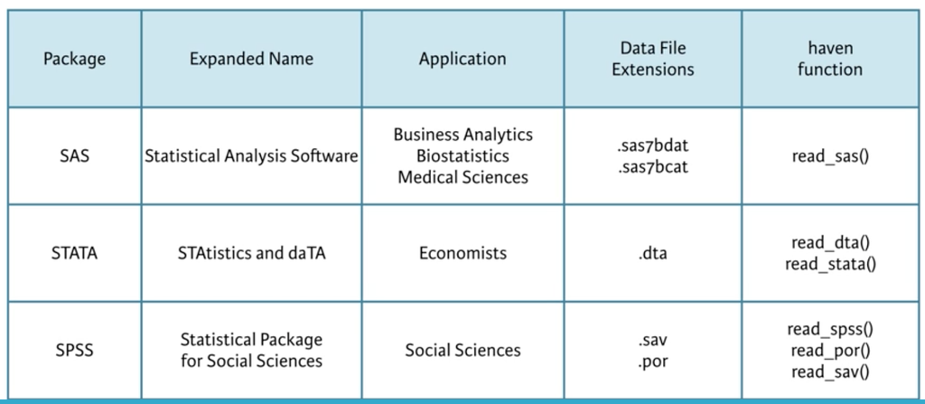

## Import SAS data with haven

- I can load the data directly from the datacamp assest directory online. Woot!

```r
# The haven package is already loaded

# Import sales.sas7bdat: sales
sales <- read_sas('http://assets.datacamp.com/course/importing_data_into_r/sales.sas7bdat')

# Display the structure of sales
str(sales)
```

```
## Classes 'tbl_df', 'tbl' and 'data.frame':    431 obs. of  4 variables:
##  $ purchase: num  0 0 1 1 0 0 0 0 0 0 ...
##  $ age     : num  41 47 41 39 32 32 33 45 43 40 ...
##  $ gender  : chr  "Female" "Female" "Female" "Female" ...
##  $ income  : chr  "Low" "Low" "Low" "Low" ...
##  - attr(*, "label")= chr "SALES"
```

## Import STATA data with haven

```r
# Import the data from the URL: sugar
sugar <- read_stata('http://assets.datacamp.com/production/course_1478/datasets/trade.dta')

# Structure of sugar
str(sugar)
```

```
## Classes 'tbl_df', 'tbl' and 'data.frame':    10 obs. of  5 variables:
##  $ Date    :Class 'labelled'  atomic [1:10] 10 9 8 7 6 5 4 3 2 1
##   .. ..- attr(*, "label")= chr "Date"
##   .. ..- attr(*, "format.stata")= chr "%9.0g"
##   .. ..- attr(*, "labels")= Named num [1:10] 1 2 3 4 5 6 7 8 9 10
##   .. .. ..- attr(*, "names")= chr [1:10] "2004-12-31" "2005-12-31" "2006-12-31" "2007-12-31" ...
##  $ Import  : atomic  37664782 16316512 11082246 35677943 9879878 ...
##   ..- attr(*, "label")= chr "Import"
##   ..- attr(*, "format.stata")= chr "%9.0g"
##  $ Weight_I: atomic  54029106 21584365 14526089 55034932 14806865 ...
##   ..- attr(*, "label")= chr "Weight_I"
##   ..- attr(*, "format.stata")= chr "%9.0g"
##  $ Export  : atomic  5.45e+07 1.03e+08 3.79e+07 4.85e+07 7.15e+07 ...
##   ..- attr(*, "label")= chr "Export"
##   ..- attr(*, "format.stata")= chr "%9.0g"
##  $ Weight_E: atomic  9.34e+07 1.58e+08 8.80e+07 1.12e+08 1.32e+08 ...
##   ..- attr(*, "label")= chr "Weight_E"
##   ..- attr(*, "format.stata")= chr "%9.0g"
##  - attr(*, "label")= chr "Written by R."
```

```r
# Convert values in Date column to dates
sugar$Date <- as.Date(as_factor(sugar$Date))

# Structure of sugar again
str(sugar)
```

```
## Classes 'tbl_df', 'tbl' and 'data.frame':    10 obs. of  5 variables:
##  $ Date    : Date, format: "2013-12-31" "2012-12-31" ...
##  $ Import  : atomic  37664782 16316512 11082246 35677943 9879878 ...
##   ..- attr(*, "label")= chr "Import"
##   ..- attr(*, "format.stata")= chr "%9.0g"
##  $ Weight_I: atomic  54029106 21584365 14526089 55034932 14806865 ...
##   ..- attr(*, "label")= chr "Weight_I"
##   ..- attr(*, "format.stata")= chr "%9.0g"
##  $ Export  : atomic  5.45e+07 1.03e+08 3.79e+07 4.85e+07 7.15e+07 ...
##   ..- attr(*, "label")= chr "Export"
##   ..- attr(*, "format.stata")= chr "%9.0g"
##  $ Weight_E: atomic  9.34e+07 1.58e+08 8.80e+07 1.12e+08 1.32e+08 ...
##   ..- attr(*, "label")= chr "Weight_E"
##   ..- attr(*, "format.stata")= chr "%9.0g"
##  - attr(*, "label")= chr "Written by R."
```

## What does the graphic tell?

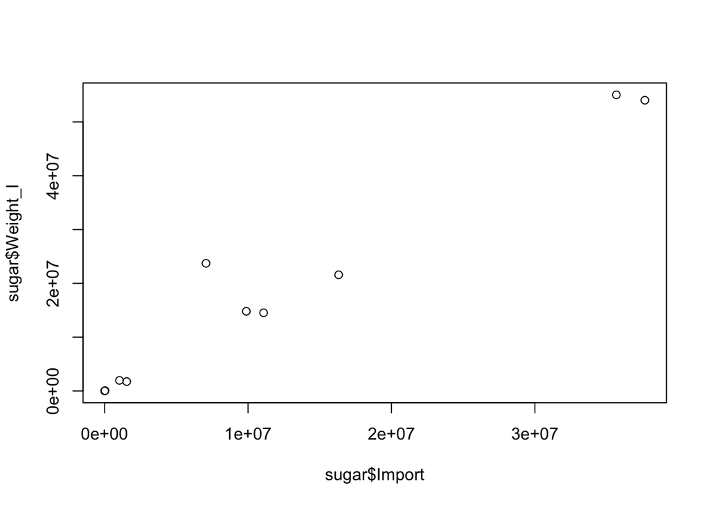

```r
sugar <- read_stata('http://assets.datacamp.com/production/course_1478/datasets/trade.dta')

plot(sugar$Import, sugar$Weight_I)
```

They are relatively positively correlated

## Import SPSS data with haven

```r
# Import person.sav: traits
traits <- read_sav('http://assets.datacamp.com/production/course_1478/datasets/person.sav')

# Summarize traits
summary(traits)
```

```
##     Neurotic      Extroversion   Agreeableness   Conscientiousness
##  Min.   : 0.00   Min.   : 5.00   Min.   :15.00   Min.   : 7.00
##  1st Qu.:18.00   1st Qu.:26.00   1st Qu.:39.00   1st Qu.:25.00
##  Median :24.00   Median :31.00   Median :45.00   Median :30.00
##  Mean   :23.63   Mean   :30.23   Mean   :44.55   Mean   :30.85
##  3rd Qu.:29.00   3rd Qu.:34.00   3rd Qu.:50.00   3rd Qu.:36.00
##  Max.   :44.00   Max.   :65.00   Max.   :73.00   Max.   :58.00
##  NA's   :14      NA's   :16      NA's   :19      NA's   :14
```

```r
# Print out a subset
subset(traits,
  subset = Extroversion > 40 & Agreeableness > 40)
```

```
## # A tibble: 8 x 4
##   Neurotic Extroversion Agreeableness Conscientiousness
##      <dbl>        <dbl>         <dbl>             <dbl>
## 1       38           43            49                29
## 2       20           42            46                31
## 3       18           42            49                31
## 4       42           43            44                29
## 5       30           42            51                24
## 6       18           42            50                25
## 7       27           45            55                23
## 8       18           43            57                34
```

## Factorize, round two

```r
# Import SPSS data from the URL: work
work <- read_sav('http://s3.amazonaws.com/assets.datacamp.com/production/course_1478/datasets/employee.sav')

# Display summary of work$GENDER
summary(work$GENDER)
```

```
##    Length     Class      Mode
##       474  labelled character
```

```r
# Convert work$GENDER to a factor
work$GENDER <- as_factor(work$GENDER)

# Display summary of work$GENDER again
summary(work$GENDER)
```

```
## Female   Male
##    216    258
```

## foreign

- `foreign` can import data from SAS, STATA, SPSS as well as SYSTAT, Weka, and others.
- It was created by the R core team and is comprehensinve, though the arguments are less consistent than `haven`.
- `foreign` cannot import .sas7bdat for some reason, but only .xport libraries. Checkout `sas7bdata` package if you don’t want to use haven

## Import STATA data with foreign (1)

```r
# The foreign package is already loaded

# Import florida.dta and name the resulting data frame florida
florida <- read.dta('http://s3.amazonaws.com/assets.datacamp.com/production/course_1478/datasets/florida.dta')

# Check tail() of florida
tail(florida)
```

```
##     gore  bush buchanan nader  total
## 62  2647  4051       27    59   6784
## 63  1399  2326       26    29   3780
## 64 97063 82214      396  2436 182109
## 65  3835  4511       46   149   8541
## 66  5637 12176      120   265  18198
## 67  2796  4983       88    93   7960
```

## Import STATA data with foreign (2)

```r
# Specify the file path using file.path(): path
path <- 'http://s3.amazonaws.com/assets.datacamp.com/production/course_1478/datasets/edequality.dta'

# Create and print structure of edu_equal_1
edu_equal_1 <- read.dta(path)
str(edu_equal_1)
```

```
## 'data.frame':    12214 obs. of  27 variables:
##  $ hhid              : num  1 1 1 2 2 3 4 4 5 6 ...
##  $ hhweight          : num  627 627 627 627 627 ...
##  $ location          : Factor w/ 2 levels "urban location",..: 1 1 1 1 1 2 2 2 1 1 ...
##  $ region            : Factor w/ 9 levels "Sofia city","Bourgass",..: 8 8 8 9 9 4 4 4 8 8 ...
##  $ ethnicity_head    : Factor w/ 4 levels "Bulgaria","Turks",..: 2 2 2 1 1 1 1 1 1 1 ...
##  $ age               : num  37 11 8 73 70 75 79 80 82 83 ...
##  $ gender            : Factor w/ 2 levels "male","female": 2 2 1 1 2 1 1 2 2 2 ...
##  $ relation          : Factor w/ 9 levels "head                      ",..: 1 3 3 1 2 1 1 2 1 1 ...
##  $ literate          : Factor w/ 2 levels "no","yes": 1 2 2 2 2 2 2 2 2 2 ...
##  $ income_mnt        : num  13.3 13.3 13.3 142.5 142.5 ...
##  $ income            : num  160 160 160 1710 1710 ...
##  $ aggregate         : num  1042 1042 1042 3271 3271 ...
##  $ aggr_ind_annual   : num  347 347 347 1635 1635 ...
##  $ educ_completed    : int  2 4 4 4 3 3 3 3 4 4 ...
##  $ grade_complete    : num  4 3 0 3 4 4 4 4 5 5 ...
##  $ grade_all         : num  4 11 8 11 8 8 8 8 13 13 ...
##  $ unemployed        : int  2 1 1 1 1 1 1 1 1 1 ...
##  $ reason_OLF        : int  NA NA NA 3 3 3 9 9 3 3 ...
##  $ sector            : int  NA NA NA NA NA NA 1 1 NA NA ...
##  $ occupation        : int  NA NA NA NA NA NA 5 5 NA NA ...
##  $ earn_mont         : num  0 0 0 0 0 0 20 20 0 0 ...
##  $ earn_ann          : num  0 0 0 0 0 0 240 240 0 0 ...
##  $ hours_week        : num  NA NA NA NA NA NA 30 35 NA NA ...
##  $ hours_mnt         : num  NA NA NA NA NA ...
##  $ fulltime          : int  NA NA NA NA NA NA 1 1 NA NA ...
##  $ hhexp             : num  100 100 100 343 343 ...
##  $ legacy_pension_amt: num  NA NA NA NA NA NA NA NA NA NA ...
##  - attr(*, "datalabel")= chr ""
##  - attr(*, "time.stamp")= chr ""
##  - attr(*, "formats")= chr  "%9.0g" "%9.0g" "%9.0g" "%9.0g" ...
##  - attr(*, "types")= int  100 100 108 108 108 100 108 108 108 100 ...
##  - attr(*, "val.labels")= chr  "" "" "location" "region" ...
##  - attr(*, "var.labels")= chr  "hhid" "hhweight" "location" "region" ...
##  - attr(*, "expansion.fields")=List of 12
##   ..$ : chr  "_dta" "_svy_su1" "cluster"
##   ..$ : chr  "_dta" "_svy_strata1" "strata"
##   ..$ : chr  "_dta" "_svy_stages" "1"
##   ..$ : chr  "_dta" "_svy_version" "2"
##   ..$ : chr  "_dta" "__XijVarLabcons" "(sum) cons"
```

[output cut: 18 more lines]

```
##   .. ..- attr(*, "names")= chr  "head                      " "spouse/partner            " "child                     " "son/daughter-in-law       " ...
##   ..$ lit     : Named int  1 2
##   .. ..- attr(*, "names")= chr  "no" "yes"
##   ..$         : Named int  1 2 3 4
##   .. ..- attr(*, "names")= chr  "never attanded" "primary" "secondary" "postsecondary"
##   ..$         : Named int  1 2
##   .. ..- attr(*, "names")= chr  "Not unemployed" "Unemployed"
##   ..$         : Named int  1 2 3 4 5 6 7 8 9 10
##   .. ..- attr(*, "names")= chr  "student" "housewife/childcare" "in retirement" "illness, disability" ...
##   ..$         : Named int  1 2 3 4 5 6 7 8 9 10
##   .. ..- attr(*, "names")= chr  "agriculture" "mining" "manufacturing" "utilities" ...
##   ..$         : Named int  1 2 3 4 5
##   .. ..- attr(*, "names")= chr  "private company" "public works program" "government,public sector, army" "private individual" ...
##   ..$         : Named int  1 2
##   .. ..- attr(*, "names")= chr  "no" "yes"
```

```r
# Create and print structure of edu_equal_2
edu_equal_2 <- read.dta(path, convert.factors=F)
str(edu_equal_2)
```

```
## 'data.frame':    12214 obs. of  27 variables:
##  $ hhid              : num  1 1 1 2 2 3 4 4 5 6 ...
##  $ hhweight          : num  627 627 627 627 627 ...
##  $ location          : int  1 1 1 1 1 2 2 2 1 1 ...
##  $ region            : int  8 8 8 9 9 4 4 4 8 8 ...
##  $ ethnicity_head    : int  2 2 2 1 1 1 1 1 1 1 ...
##  $ age               : num  37 11 8 73 70 75 79 80 82 83 ...
##  $ gender            : int  2 2 1 1 2 1 1 2 2 2 ...
##  $ relation          : int  1 3 3 1 2 1 1 2 1 1 ...
##  $ literate          : int  1 2 2 2 2 2 2 2 2 2 ...
##  $ income_mnt        : num  13.3 13.3 13.3 142.5 142.5 ...
##  $ income            : num  160 160 160 1710 1710 ...
##  $ aggregate         : num  1042 1042 1042 3271 3271 ...
##  $ aggr_ind_annual   : num  347 347 347 1635 1635 ...
##  $ educ_completed    : int  2 4 4 4 3 3 3 3 4 4 ...
##  $ grade_complete    : num  4 3 0 3 4 4 4 4 5 5 ...
##  $ grade_all         : num  4 11 8 11 8 8 8 8 13 13 ...
##  $ unemployed        : int  2 1 1 1 1 1 1 1 1 1 ...
##  $ reason_OLF        : int  NA NA NA 3 3 3 9 9 3 3 ...
##  $ sector            : int  NA NA NA NA NA NA 1 1 NA NA ...
##  $ occupation        : int  NA NA NA NA NA NA 5 5 NA NA ...
##  $ earn_mont         : num  0 0 0 0 0 0 20 20 0 0 ...
##  $ earn_ann          : num  0 0 0 0 0 0 240 240 0 0 ...
##  $ hours_week        : num  NA NA NA NA NA NA 30 35 NA NA ...
##  $ hours_mnt         : num  NA NA NA NA NA ...
##  $ fulltime          : int  NA NA NA NA NA NA 1 1 NA NA ...
##  $ hhexp             : num  100 100 100 343 343 ...
##  $ legacy_pension_amt: num  NA NA NA NA NA NA NA NA NA NA ...
##  - attr(*, "datalabel")= chr ""
##  - attr(*, "time.stamp")= chr ""
##  - attr(*, "formats")= chr  "%9.0g" "%9.0g" "%9.0g" "%9.0g" ...
##  - attr(*, "types")= int  100 100 108 108 108 100 108 108 108 100 ...
##  - attr(*, "val.labels")= chr  "" "" "location" "region" ...
##  - attr(*, "var.labels")= chr  "hhid" "hhweight" "location" "region" ...
##  - attr(*, "expansion.fields")=List of 12
##   ..$ : chr  "_dta" "_svy_su1" "cluster"
##   ..$ : chr  "_dta" "_svy_strata1" "strata"
##   ..$ : chr  "_dta" "_svy_stages" "1"
##   ..$ : chr  "_dta" "_svy_version" "2"
##   ..$ : chr  "_dta" "__XijVarLabcons" "(sum) cons"
```

[output cut: 18 more lines]

```
##   .. ..- attr(*, "names")= chr  "head                      " "spouse/partner            " "child                     " "son/daughter-in-law       " ...
##   ..$ lit     : Named int  1 2
##   .. ..- attr(*, "names")= chr  "no" "yes"
##   ..$         : Named int  1 2 3 4
##   .. ..- attr(*, "names")= chr  "never attanded" "primary" "secondary" "postsecondary"
##   ..$         : Named int  1 2
##   .. ..- attr(*, "names")= chr  "Not unemployed" "Unemployed"
##   ..$         : Named int  1 2 3 4 5 6 7 8 9 10
##   .. ..- attr(*, "names")= chr  "student" "housewife/childcare" "in retirement" "illness, disability" ...
##   ..$         : Named int  1 2 3 4 5 6 7 8 9 10
##   .. ..- attr(*, "names")= chr  "agriculture" "mining" "manufacturing" "utilities" ...
##   ..$         : Named int  1 2 3 4 5
##   .. ..- attr(*, "names")= chr  "private company" "public works program" "government,public sector, army" "private individual" ...
##   ..$         : Named int  1 2
##   .. ..- attr(*, "names")= chr  "no" "yes"
```

```r
# Create and print structure of edu_equal_3
edu_equal_3 <- read.dta(path, convert.underscore=T)
str(edu_equal_3)
```

```
## 'data.frame':    12214 obs. of  27 variables:
##  $ hhid              : num  1 1 1 2 2 3 4 4 5 6 ...
##  $ hhweight          : num  627 627 627 627 627 ...
##  $ location          : Factor w/ 2 levels "urban location",..: 1 1 1 1 1 2 2 2 1 1 ...
##  $ region            : Factor w/ 9 levels "Sofia city","Bourgass",..: 8 8 8 9 9 4 4 4 8 8 ...
##  $ ethnicity.head    : Factor w/ 4 levels "Bulgaria","Turks",..: 2 2 2 1 1 1 1 1 1 1 ...
##  $ age               : num  37 11 8 73 70 75 79 80 82 83 ...
##  $ gender            : Factor w/ 2 levels "male","female": 2 2 1 1 2 1 1 2 2 2 ...
##  $ relation          : Factor w/ 9 levels "head                      ",..: 1 3 3 1 2 1 1 2 1 1 ...
##  $ literate          : Factor w/ 2 levels "no","yes": 1 2 2 2 2 2 2 2 2 2 ...
##  $ income.mnt        : num  13.3 13.3 13.3 142.5 142.5 ...
##  $ income            : num  160 160 160 1710 1710 ...
##  $ aggregate         : num  1042 1042 1042 3271 3271 ...
##  $ aggr.ind.annual   : num  347 347 347 1635 1635 ...
##  $ educ.completed    : int  2 4 4 4 3 3 3 3 4 4 ...
##  $ grade.complete    : num  4 3 0 3 4 4 4 4 5 5 ...
##  $ grade.all         : num  4 11 8 11 8 8 8 8 13 13 ...
##  $ unemployed        : int  2 1 1 1 1 1 1 1 1 1 ...
##  $ reason.OLF        : int  NA NA NA 3 3 3 9 9 3 3 ...
##  $ sector            : int  NA NA NA NA NA NA 1 1 NA NA ...
##  $ occupation        : int  NA NA NA NA NA NA 5 5 NA NA ...
##  $ earn.mont         : num  0 0 0 0 0 0 20 20 0 0 ...
##  $ earn.ann          : num  0 0 0 0 0 0 240 240 0 0 ...
##  $ hours.week        : num  NA NA NA NA NA NA 30 35 NA NA ...
##  $ hours.mnt         : num  NA NA NA NA NA ...
##  $ fulltime          : int  NA NA NA NA NA NA 1 1 NA NA ...
##  $ hhexp             : num  100 100 100 343 343 ...
##  $ legacy.pension.amt: num  NA NA NA NA NA NA NA NA NA NA ...
##  - attr(*, "datalabel")= chr ""
##  - attr(*, "time.stamp")= chr ""
##  - attr(*, "formats")= chr  "%9.0g" "%9.0g" "%9.0g" "%9.0g" ...
##  - attr(*, "types")= int  100 100 108 108 108 100 108 108 108 100 ...
##  - attr(*, "val.labels")= chr  "" "" "location" "region" ...
##  - attr(*, "var.labels")= chr  "hhid" "hhweight" "location" "region" ...
##  - attr(*, "expansion.fields")=List of 12
##   ..$ : chr  "_dta" "_svy_su1" "cluster"
##   ..$ : chr  "_dta" "_svy_strata1" "strata"
##   ..$ : chr  "_dta" "_svy_stages" "1"
##   ..$ : chr  "_dta" "_svy_version" "2"
##   ..$ : chr  "_dta" "__XijVarLabcons" "(sum) cons"
```

[output cut: 18 more lines]

```
##   .. ..- attr(*, "names")= chr  "head                      " "spouse/partner            " "child                     " "son/daughter-in-law       " ...
##   ..$ lit     : Named int  1 2
##   .. ..- attr(*, "names")= chr  "no" "yes"
##   ..$         : Named int  1 2 3 4
##   .. ..- attr(*, "names")= chr  "never attanded" "primary" "secondary" "postsecondary"
##   ..$         : Named int  1 2
##   .. ..- attr(*, "names")= chr  "Not unemployed" "Unemployed"
##   ..$         : Named int  1 2 3 4 5 6 7 8 9 10
##   .. ..- attr(*, "names")= chr  "student" "housewife/childcare" "in retirement" "illness, disability" ...
##   ..$         : Named int  1 2 3 4 5 6 7 8 9 10
##   .. ..- attr(*, "names")= chr  "agriculture" "mining" "manufacturing" "utilities" ...
##   ..$         : Named int  1 2 3 4 5
##   .. ..- attr(*, "names")= chr  "private company" "public works program" "government,public sector, army" "private individual" ...
##   ..$         : Named int  1 2
##   .. ..- attr(*, "names")= chr  "no" "yes"
```

## Do you know your data?

```r
## How many observations/individuals from Bulgaria have an income above 1000?
nrow(subset(edu_equal_1, ethnicity_head == 'Bulgaria' & income > 1000))
```

```
## [1] 8997
```

## Import SPSS data with foreign (1)

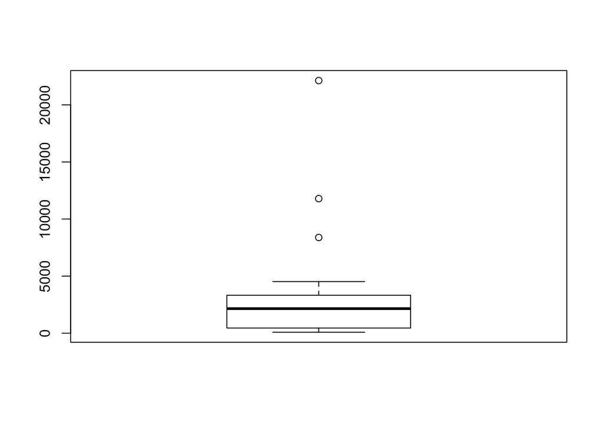

```r
# Import international.sav as a data frame: demo
demo <- read.spss('http://s3.amazonaws.com/assets.datacamp.com/production/course_1478/datasets/international.sav', to.data.frame=T)

# Create boxplot of gdp variable of demo
boxplot(demo$gdp)
```

## Excursion: Correlation

```r
## What is the correlation coefficient for the two numerical variables gdp and f_illit (female illiteracy rate)?
cor(demo$gdp, demo$f_illit)
```

```
## [1] -0.4476856
```

## Import SPSS data with foreign (2)

```r
path <- 'http://s3.amazonaws.com/assets.datacamp.com/production/course_1478/datasets/international.sav'

# Import international.sav as demo_1
demo_1 <- read.spss(path, to.data.frame=T)

# Print out the head of demo_1
head(demo_1)
```

```
##   id              country  contint m_illit f_illit lifeexpt  gdp
## 1  1 Argentina            Americas     3.0     3.0       16 3375
## 2  2 Benin                  Africa    45.2    74.5        7  521
## 3  3 Burundi                Africa    33.2    48.1        5   86
## 4  4 Chile                Americas     4.2     4.4       14 4523
## 5  5 Dominican Republic   Americas    12.0    12.7       12 2408
## 6  6 El Salvador          Americas    17.6    22.9       11 2302
```

```r
# Import international.sav as demo_2
demo_2 <- read.spss(path, to.data.frame=T, use.value.labels=F)

# Print out the head of demo_2
head(demo_2)
```

```
##   id              country contint m_illit f_illit lifeexpt  gdp
## 1  1 Argentina                  2     3.0     3.0       16 3375
## 2  2 Benin                      1    45.2    74.5        7  521
## 3  3 Burundi                    1    33.2    48.1        5   86
## 4  4 Chile                      2     4.2     4.4       14 4523
## 5  5 Dominican Republic         2    12.0    12.7       12 2408
## 6  6 El Salvador                2    17.6    22.9       11 2302
```

```r
str(demo_2)
```

```
## 'data.frame':    20 obs. of  7 variables:
##  $ id      : num  1 2 3 4 5 6 7 8 9 10 ...
##  $ country : Factor w/ 20 levels "Argentina           ",..: 1 2 3 4 5 6 7 8 9 10 ...
##  $ contint : atomic  2 1 1 2 2 2 1 4 3 3 ...
##   ..- attr(*, "value.labels")= Named chr  "4" "3" "2" "1"
##   .. ..- attr(*, "names")= chr  "Europe" "Asia" "Americas" "Africa"
##  $ m_illit : num  3 45.2 33.2 4.2 12 17.6 37.1 0.6 16.5 23 ...
##  $ f_illit : num  3 74.5 48.1 4.4 12.7 22.9 54.3 0.7 29.6 39.1 ...
##  $ lifeexpt: num  16 7 5 14 12 11 7 15 11 9 ...
##  $ gdp     : num  3375 521 86 4523 2408 ...
##  - attr(*, "variable.labels")= Named chr  " " "Country" "Continent" "Male Illiteracy Rate (%)" ...
##   ..- attr(*, "names")= chr  "id" "country" "contint" "m_illit" ...
##  - attr(*, "codepage")= int 1252
```